# Part II - FordGoBike

## by Nyaga Derrick

## Investigation Overview

My intentions were to get to know how long trips fair across a week. Distrubtion of ages, Distribtion of trips in terms of times of day. and trip duration and how various features or columns in the dataset relate with user type(customer and subsciber)

## Dataset Overview

The data includes information regarding 183,412 rides with 16 columns, they include: duration_sec, start_time, end_time, start_station_id, start_station_name, start_station_latitude, start_station_longitude, end_station_id, end_station_name, end_station_latitude, end_station_longitude, bike_id, user_type, member_birth_year, member_gender, bike_share_for_all_trip

After data cleaning and combination of columns resulted to the having the following columns: start_time, end_time , start_station_name , end_station_name, user_type, member_gender , day_of_week , start_hour , time_of_day, duration_min, member_age, age_group, member_age_ratio.

Hence resulting to 183,412 rides and 13 columns.

## Trips taken in terms of week days

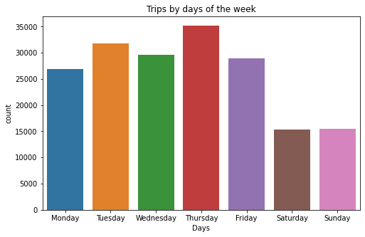

## Distribution of trip duration

The duration picks at around 10 mins.

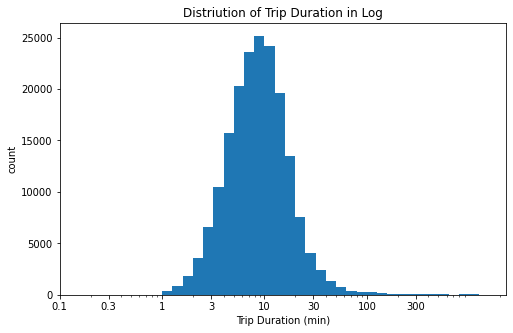

## Distribution in terms of time of day

Most journeys is the afternoon (12:00–17:59), followed by the morning (00:00 - 11:59 hours of the day)

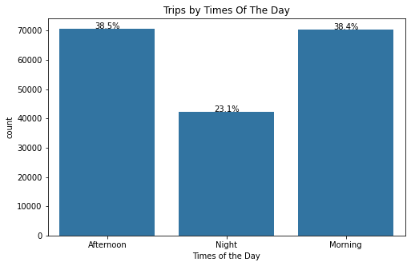

## Distribution Of Ages

Most people between the age of 31-40 use the fordgobike more as compared to other age ratios, while age 21-30 is the second highest.

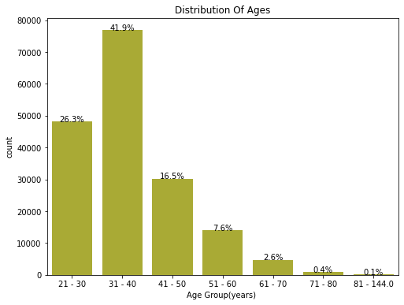

## Average Trip Duration Per Age Group

The ages between 21 -80 not including 80-144 as they are out the scope we see that the duration of trips is almost similar and ages 51-70 have the highest duration

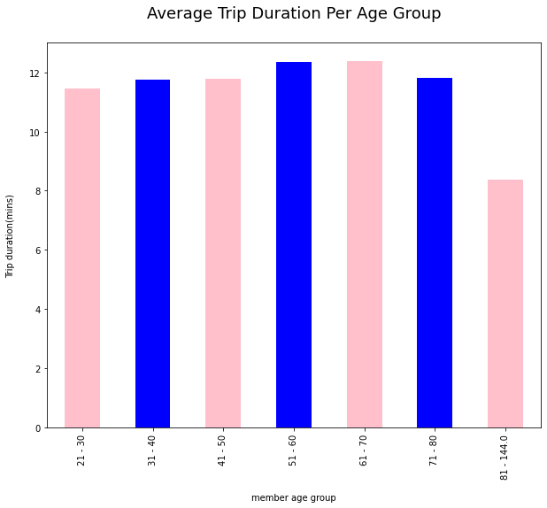

## User type day of the week FordGoBike usage

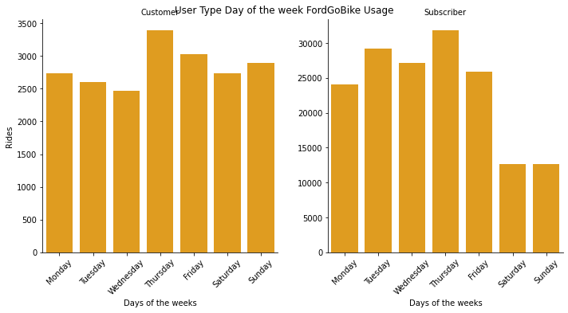

## User type time of the day FordGoBike usage

Customers do the most trips in the afternoons ,averangely in the morning and lower trips at night while for subscribers most trips are in the morning and afterrnoon

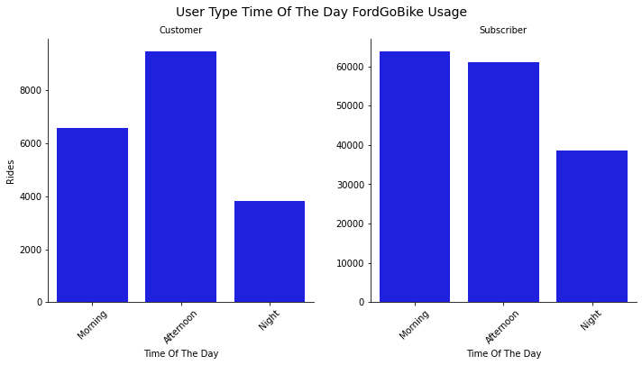

## Average Trip duration for each user type

Customer rides took longer through out the week as comapred to the subscribers

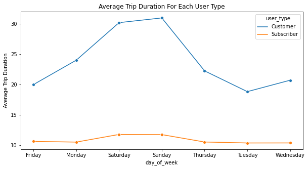

## Average trip duration for each user type across time of day

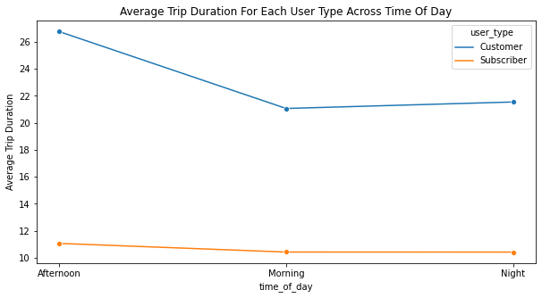